# Assignment 3 ST404/ST684

Saad Siddiqui 23250068

5:52:44 PM 12 April, 2024

```r
library(yardstick)
library(ggplot2)
library(class)
library(MASS)
library(ISLR2)
library(pROC)
```

#### Question 2

```r
a<- data.frame(Group = c("A", "A", "A", "A", "A", "A", "B", "B", "B", "B"),
                   Prob = c(0.418, 0.865, 0.569, 0.529, 0.721, 0.399, 0.082, 0.194, 0.381, 0.416))
a$Group = as.factor(a$Group)
pred <- factor(ifelse(a$Prob >= 0.5, "A", "B"))
```

Predicted Classes with Threshold of 0.5:

Any probability >= 0.5 is classified as Group A, otherwise as Group B.

```r
confusion_matrix <- table(Predicted=pred,true=a$Group)
error_rate <- 1 - sum(diag(confusion_matrix)) / sum(confusion_matrix)
print(error_rate)
```

```
## [1] 0.2
```

```r
false_positive_rate <- confusion_matrix["B", "A"] / sum(confusion_matrix["B", ])
print(false_positive_rate)
```

```
## [1] 0.3333333
```

```r
true_positive_rate <- confusion_matrix["A", "A"] / sum(confusion_matrix["A", ])
print(true_positive_rate)
```

```
## [1] 1
```

```r
a$Predicted_02 <- ifelse(a$Prob >= 0.2, "A", "B")
confusion_matrix_02 <- table(a$Group, a$Predicted_02)
false_positive_rate_02 <- confusion_matrix_02["B", "A"] / sum(confusion_matrix_02["B", ])
print(false_positive_rate_02)
```

```
## [1] 0.5
```

```r
true_positive_rate_02 <- confusion_matrix_02["A", "A"] / sum(confusion_matrix_02["A", ])
print(true_positive_rate_02)
```

```
## [1] 1
```

```r
my_list <- list(
  Group = c("A", "A", "A", "A", "A", "A", "B", "B", "B", "B"),
  Prob = c(0.418, 0.865, 0.569, 0.529, 0.721, 0.399, 0.082, 0.194, 0.381, 0.416)
)

# Convert list to dataframe
x <- data.frame(my_list)

# Print the dataframe
print(x)
```

```
##    Group  Prob
## 1      A 0.418
## 2      A 0.865
## 3      A 0.569
## 4      A 0.529
## 5      A 0.721
## 6      A 0.399
## 7      B 0.082
## 8      B 0.194
## 9      B 0.381
## 10     B 0.416
```

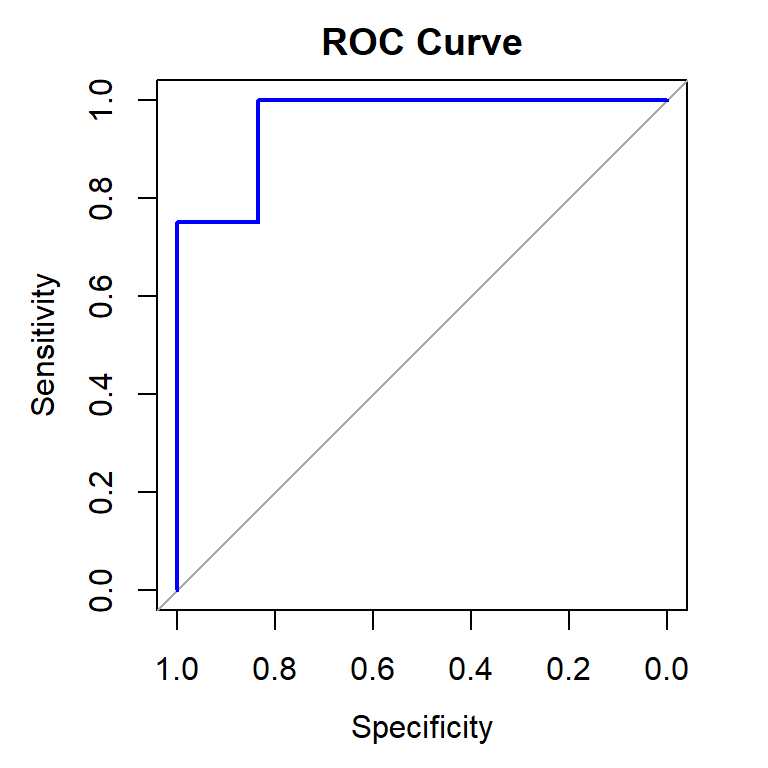

```r
# Assuming roc_data contains your predicted probabilities and true labels
library(pROC)

# Calculate ROC curve
roc_data <- roc(x$Group, x$Prob)

# Plot ROC curve
plot(roc_data, main = "ROC Curve", col = "blue", lwd = 2)
```

```r
# Calculate Area under ROC curve
auc_val <- auc(roc_data)
```

```r
# Create a dataframe from the given data
y <- data.frame(
  Group = c("A", "A", "A", "A", "A", "A", "B", "B", "B", "B"),
  Prob1 = c(0.418, 0.965, 0.669, 0.529, 0.821, 0.399, 0.082, 0.194, 0.381, 0.416)
)

# Print the dataframe
print(y)
```

```
##    Group Prob1
## 1      A 0.418
## 2      A 0.965
## 3      A 0.669
## 4      A 0.529
## 5      A 0.821
## 6      A 0.399
## 7      B 0.082
## 8      B 0.194
## 9      B 0.381
## 10     B 0.416
```

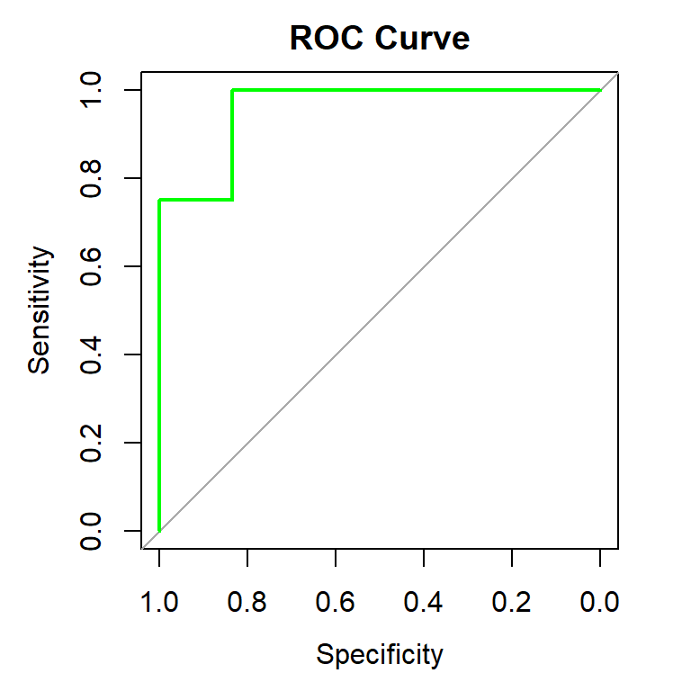

```r
# Assuming you have your dataframe named 'my_dataframe'
# Calculate ROC curve
roc_data <- roc(as.factor(y$Group), y$Prob1)

# Plot ROC curve
plot(roc_data, main = "ROC Curve", col = "green", lwd = 2)
```

```r
# Calculate Area under ROC curve
auc_val <- auc(roc_data)
print(auc_val)
```

```
## Area under the curve: 0.9583
```

It appears that the area under the ROC curve (AUC) for both classifiers is the same, with a value of approximately 0.9583 for each.

```r
m <- median(Auto$mpg)
Auto$mpg01 <- factor(ifelse(Auto$mpg <= m, 0, 1))
 set.seed(1)
s <- sample(nrow(Auto), round(.5*nrow(Auto)))
Atrain <- Auto[s,]
Atest <- Auto[-s,]
```

```r
model <- glm(mpg01 ~ displacement + horsepower + weight + acceleration, data = Atrain, family = binomial)

pred<- predict(model, newdata = Atest, type = "response")

# Convert predicted probabilities to binary predictions
pred_classes <- ifelse(pred > 0.5, 1, 0)

# Calculate the test error
test_error <- mean(pred_classes != Atest$mpg01)
cat("Test Error:", test_error, "\n")
```

```
## Test Error: 0.127551
```

```r
Atest$pred <- predict(model, newdata = Atest, type = "response")
multi_metric <- metric_set( mn_log_loss)
multi_metric(Atest, "mpg01", "pred",event_level="second")
```

```
## # A tibble: 1 × 3
##   .metric     .estimator .estimate
##   <chr>       <chr>          <dbl>
## 1 mn_log_loss binary         0.293
```

```r
lda_model <- lda(mpg01 ~ displacement + horsepower + weight + acceleration, data = Atrain)
lda_model
```

```
## Call:
## lda(mpg01 ~ displacement + horsepower + weight + acceleration,
##     data = Atrain)
##
## Prior probabilities of groups:
##         0         1
## 0.4795918 0.5204082
##
## Group means:
##   displacement horsepower   weight acceleration
## 0     276.8404  129.40426 3620.723     14.60213
## 1     113.6275   77.92157 2319.118     16.73922
##
## Coefficients of linear discriminants:
##                       LD1
## displacement -0.015170885
## horsepower    0.013587500
## weight       -0.000643527
## acceleration  0.014893269
```

```r
lda_predictions <- predict(lda_model, newdata = Atest)
lda_probs <- as.numeric(lda_predictions$posterior[, 2])  # Probability of class 1 (mpg01 = 1)
lda_pred_classes <- ifelse(lda_probs > 0.5, 1, 0)

# Calculate the test error
lda_test_error <- mean(lda_pred_classes != Atest$mpg01)
cat("Test Error:", lda_test_error, "\n")
```

```
## Test Error: 0.127551
```

```r
# Calculate the test set log loss
Atest$pred = predict(lda_model, Atest)$posterior[,"1"]

multi_metric <- metric_set( mn_log_loss)
multi_metric(Atest, "mpg01", "pred",event_level="second")
```

```
## # A tibble: 1 × 3
##   .metric     .estimator .estimate
##   <chr>       <chr>          <dbl>
## 1 mn_log_loss binary         0.439
```

The Linear Discriminant Analysis (LDA) model considers four predictor variables: displacement, horsepower, weight, and acceleration, each associated with two classes (0 and 1 for mpg01). This results in 8 parameters (mean and variance) for each predictor variable, totaling 4 × 2 × 2 = 16 parameters.

Additionally, one parameter is dedicated to the prior probability of one of the classes, as the prior probability of the other class is determined by the prior of this class.

Consequently, the LDA model utilizes a total of 17 parameters.

```r
qda <- qda(mpg01 ~ displacement + horsepower + weight + acceleration, data = Atrain)
qda_predictions <- predict(qda, newdata = Atest)
qda_probs <- as.numeric(qda_predictions$posterior[, 2])
qda_pred_classes <- ifelse(qda_probs > 0.5, 1, 0)

# Calculate the test error
qda_test_error <- mean(qda_pred_classes != Atest$mpg01)
cat("Test Error:", qda_test_error, "\n")
```

```
## Test Error: 0.127551
```

```r
# Calculate the test set log loss
Atest$pred = predict(qda, Atest)$posterior[,"1"]
yardstick::mn_log_loss(Atest, "mpg01", "pred",event_level="second" )
```

```
## # A tibble: 1 × 3
##   .metric     .estimator .estimate
##   <chr>       <chr>          <dbl>
## 1 mn_log_loss binary         0.612
```

Prior probabilities: 2 parameters Class counts: 2 parameters Means matrix: 4×2=8 parameters

Scaling matrix: square of 4 =16 parameters (as scaling is quadratic in QDA)

Log-determinants of covariance matrices: 2 parameters

Total parameters:

2+2+8+16+2=30

Therefore, the QDA model uses 30 parameters in total.

```r
# Load necessary libraries
library(caret)

# Create a sample for training and testing
s <- sample(nrow(Auto), round(0.5 * nrow(Auto)))
Atrain <- Auto[s, ]
Atest <- Auto[-s, ]

# Define predictors and response variable
predictors <- c("displacement", "horsepower", "weight", "acceleration")
response <- "mpg01"

# Preprocess the training data
preproc_train <- preProcess(Atrain[predictors], method = c("center", "scale"))
scaled_train <- predict(preproc_train, Atrain[predictors])
scaled_test <- predict(preproc_train, Atest[predictors])

# KNN with k = 5
knn_model_5 <- train(x = scaled_train, y = Atrain[[response]],
                     method = "knn", trControl = trainControl(method = "cv"),
                     tuneGrid = expand.grid(k = 5))

# KNN with k = 30
knn_model_30 <- train(x = scaled_train, y = Atrain[[response]],
                      method = "knn", trControl = trainControl(method = "cv"),
                      tuneGrid = expand.grid(k = 30))

# Predictions on the test set
predictions_5 <- predict(knn_model_5, scaled_test)
predictions_30 <- predict(knn_model_30, scaled_test)

# Calculate accuracy on the test set for k = 5 and k = 30
accuracy_5 <- mean(predictions_5 == Atest[[response]])
accuracy_30 <- mean(predictions_30 == Atest[[response]])

cat("Accuracy for k = 5:", accuracy_5, "\n")
```

```
## Accuracy for k = 5: 0.9132653
```

```r
cat("Accuracy for k = 30:", accuracy_30, "\n")
```

```
## Accuracy for k = 30: 0.9081633
```